# Aula 2 - Análise descritiva de dados usando R

```r
#Apagar todos os objetos da memoria
rm(list=ls())
```

# Estatística Descritiva

Estatística Descritiva é a **etapa inicial** da análise utilizada para descrever e **resumir os dados**. A disponibilidade de uma grande quantidade de dados e de métodos computacionais muito eficientes revigorou esta área da estatística (Lachos).

# Variáveis

Qualquer característica associada a uma população.

As variáveis podem ser classificadas em:

1. Qualitativas: são as características definidas por várias categorias, ou seja, representam uma classificação dos indivíduos. Exemplo: Região de procedencia e grau de instrução.

   1.1 Nominais: Não existe nenhuma ordenação nas possíveis realizações. Exemplo: Região de procedencia. 1.2 Ordinais: Existe uma ordem de seus resultados. Exemplo: Grau de instrução
2. Quantitativas: são as características que podem ser medidas em uma escala quantitativa. Exemplo: Numero de filhos e Salarios.

   2.1 Discretas: cujos possíveis valores formam um conjunto finito ou enumerável. Exemplo: Numero de filhos. 2.2 Contínuas: cujos possíveis valores pertencem a um intervalo de numeros reais. Exemplo: Salario, estatura e peso

# Exemplo: Tabela 2.1 do livro Estatistica Basica (Morettin & Bussab)

```r
#Ler os dados
tab21 = read.table("tabela2.1.txt", sep=";", dec=",", header = TRUE)

#Classe do objeto
class(tab21)
```

```
## [1] "data.frame"
```

```r
#Nomes das colunas do objeto
names(tab21)
```

```
## [1] "N"               "estado_civil"    "grau_instrucao"  "n_filhos"
## [5] "salario"         "idade_anos"      "idade_meses"     "reg_procedencia"
```

```r
#Verificar o tipo de variável de cada coluna do data.frame
str(tab21)
```

```
## 'data.frame':    36 obs. of  8 variables:
##  $ N              : int  1 2 3 4 5 6 7 8 9 10 ...
##  $ estado_civil   : Factor w/ 2 levels "casado","solteiro": 2 1 1 2 2 1 2 2 1 2 ...
##  $ grau_instrucao : Factor w/ 3 levels "ensino fundamental",..: 1 1 1 2 1 1 1 1 2 2 ...
##  $ n_filhos       : int  NA 1 2 NA NA 0 NA NA 1 NA ...
##  $ salario        : num  4 4.56 5.25 5.73 6.26 6.66 6.86 7.39 7.59 7.44 ...
##  $ idade_anos     : int  26 32 36 20 40 28 41 43 34 23 ...
##  $ idade_meses    : int  3 10 5 10 7 0 0 4 10 6 ...
##  $ reg_procedencia: Factor w/ 3 levels "capital","interior",..: 2 1 1 3 3 2 2 1 1 3 ...
```

```r
#Imprimir as primeiras linhas do data.frame
head(tab21)
```

```
##   N estado_civil     grau_instrucao n_filhos salario idade_anos
## 1 1     solteiro ensino fundamental       NA    4.00         26
## 2 2       casado ensino fundamental        1    4.56         32
## 3 3       casado ensino fundamental        2    5.25         36
## 4 4     solteiro       ensino médio       NA    5.73         20
## 5 5     solteiro ensino fundamental       NA    6.26         40
## 6 6       casado ensino fundamental        0    6.66         28
##   idade_meses reg_procedencia
## 1           3        interior
## 2          10         capital
## 3           5         capital
## 4          10           outra
## 5           7           outra
## 6           0        interior
```

```r
#Tabela de Frequencia Absoluta
tabFAbs = table(tab21$reg_procedencia)

tabFAbs
```

```
##
##  capital interior    outra
##       11       12       13
```

```r
#Tabela de Frequencia Relativa
tabFRel = prop.table(tabFAbs)

tabFRel
```

```
##
##   capital  interior     outra
## 0.3055556 0.3333333 0.3611111
```

# Gráficos para variáveis qualitativas e quantitativas discretas

## Gráficos de barras

O gráfico em barras consiste em construir retangulos, em que uma das dimensões é proporcional a frequencia absoluta ou relativa e a outra é arbitraria, porem igual para todos os retangulos. Essas barras são dispostas paralelamente umas às outras

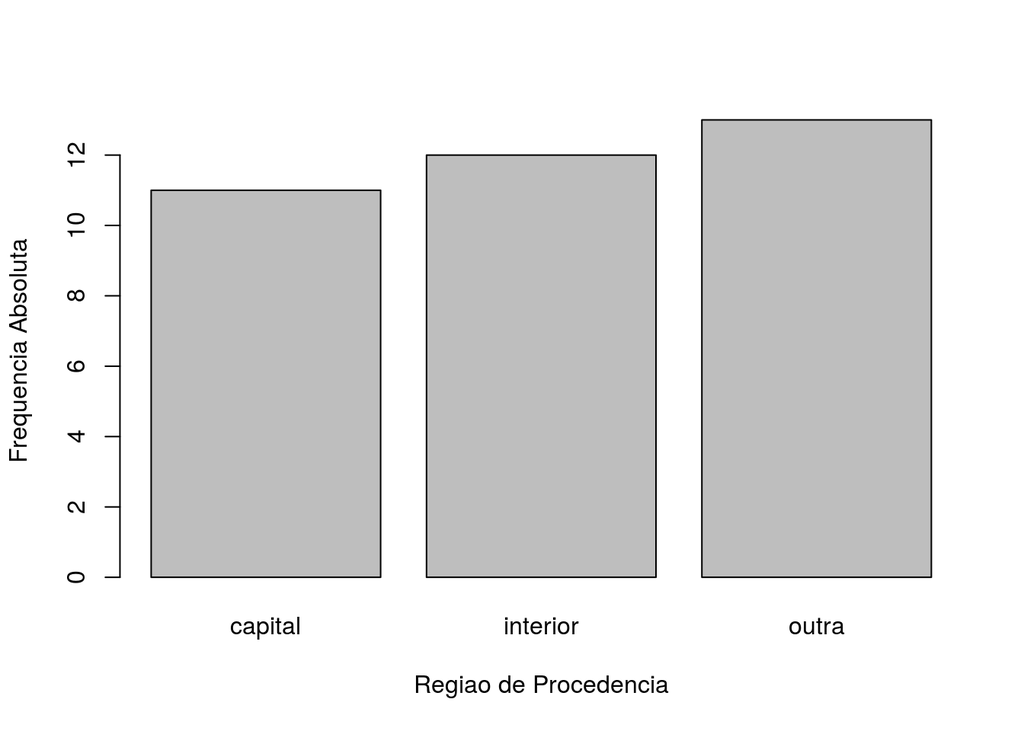

```r
#Grafico de barras - Frequencia Absoluta
barplot(tabFAbs, xlab = "Regiao de Procedencia", ylab = "Frequencia Absoluta")
```

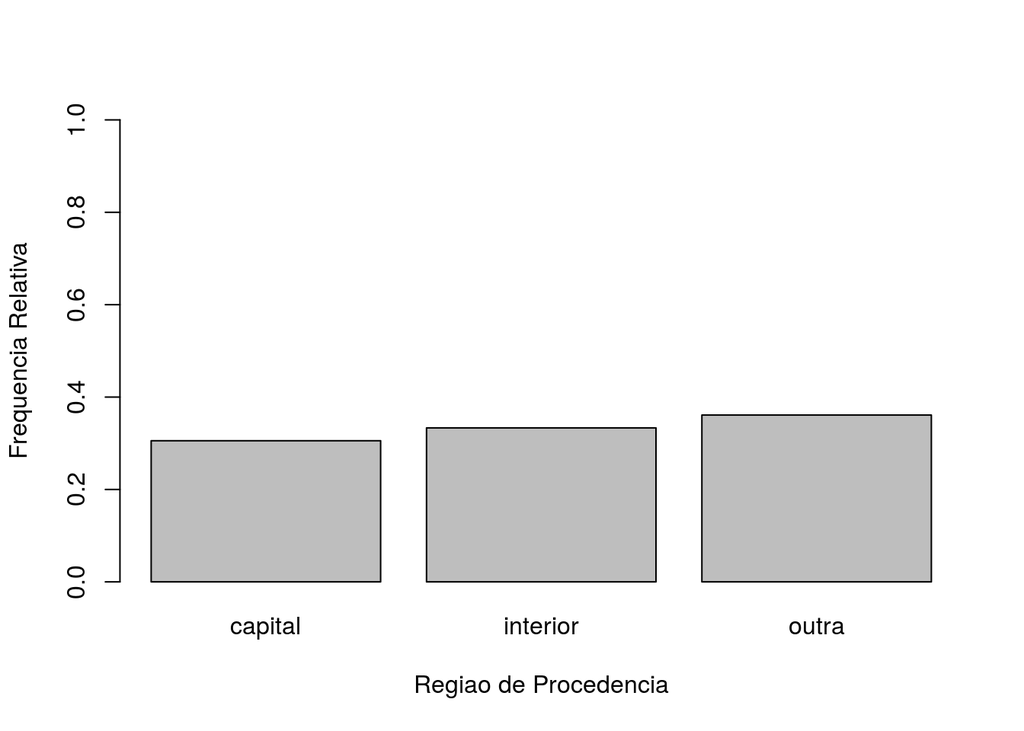

```r
#Graficos de barras - Frequencia Relativa
barplot(tabFRel, xlab = "Regiao de Procedencia", ylab = "Frequencia Relativa", ylim=c(0,1))
```

## Gráfico de composição

Gráfico de composição em setores, sendo em forma de “pizza” o mais conhecido, consiste num circulo de raio arbitrario, representando o todo, dividido em setores, que correspondem as partes de maneira proporcional.

```r
#Rotulo com as porcentagens

names(tabFAbs)
```

```
## [1] "capital"  "interior" "outra"
```

```r
100*round(tabFRel,2)
```

```
##
##  capital interior    outra
##       31       33       36
```

```r
lab = paste(names(tabFAbs)," ",100*round(tabFRel,2), "%",sep="")

lab
```

```
## [1] "capital 31%"  "interior 33%" "outra 36%"
```

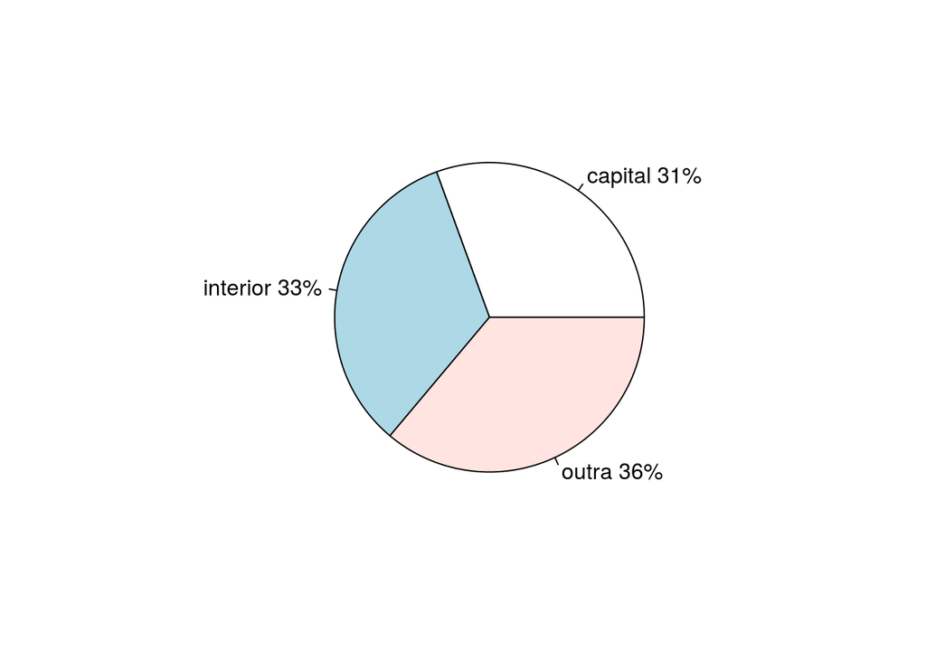

```r
#Grafico de pizza
pie(tabFAbs,labels = lab)
```

# Gráficos para variáveis quantitativas contínuas

## Histogramas

Um histograma é uma representação visual da distribuição de um cojunto de dados. Matematicamente, o histograma é um gráfico de barras contíguas, com as bases proporcionais aos intervalos de classes $\Delta$ e a área de cada retangulo proporcional à respectiva frequencia $f_i$. Para que a área do retangulo respectivo seja proporcional a $f_i$, a sua altura deve ser proporcional a $\frac{f_i}{\Delta}$, que é chamada densidade de frequencia da i-ésima classe. Com essa convenção, a área total do histograma será igual a 1.

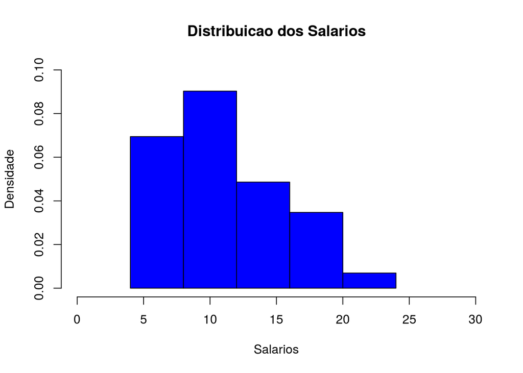

```r
#Histogramas - Estatistica Basica Morettin & Bussab

hist(tab21$salario,breaks=seq(4,24,by=4), prob=TRUE, xlab="Salarios",
     ylab = "Densidade", col="blue", ylim=c(0,0.1), xlim=c(0,30),
     main="Distribuicao dos Salarios")
```

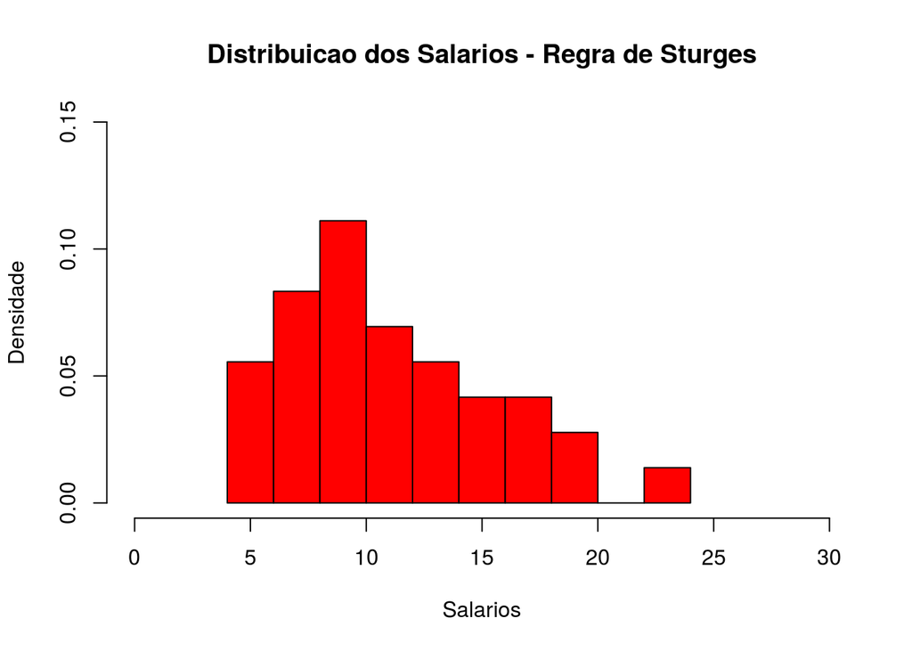

```r
#Faz um histograma para os dados de salario, que o eixo das abcissas
#inicia no ponto 4 e termina no 24 com intervalos de classe de 4 unidades.
#O limite inferior do eixo das ordenadas eh zero e o limite superior eh
#0.1
#O limite inferior do eixo das abscissas eh zero e o limite superior eh
#30

#Histograma com a regra de Sturges

hist(tab21$salario,breaks= nclass.Sturges(tab21$salario), prob=TRUE, xlab="Salarios", ylab = "Densidade", col="red", ylim=c(0,0.15), xlim=c(0,30),
     main="Distribuicao dos Salarios - Regra de Sturges")
```